# Serial Measurement Analysis

Patrick Ward

6/2/2023

## Intro

In the applied setting we often deal with longotudinal data collected on an athlete over time (serial measurement). Consequently, this is a bit different of a testing environment than the traditional test-retest type of analysis that is conducted under more controlled settings (and used for subsequent reliability analysis). While we can (and should) conduct test-retest analysis of the testing procedures we utilize, in order to explore the systematic and unsystematic error of the test (in a controlled environment), we should also be mindful that the week-to-week variance that an athlete may display in a test throughout a competitive season may not be adequately reflected in the test-retest trial (e.g., there might be more variation in weekly testing due to a number of different factors that can influence an athletes performance during the competitive season – injury, psychological mood, fatigue, etc.). As such, practitioners may benefit from complimenting their test-retest reliability studies with alternative methods for exploring week-to-week change. Additionally, in the applied setting (especially at the elite level) conducting a test-retest trial may be challenging given scheduling constraints and athlete compliance. Thus, establishing weekly variance and meaningful change values utilizing serial measurements may be more advantageous for this situation.

The goal of this tutorial is to evaluate serial counter movement jump height, across a season, for NFL football players and provide a few different approaches to exploring weekly variance and determining if a change is outside of the “norm” and worth discussing among the performance staff and perhaps creating an intervention for.

**Key References:**

1. De vet, Terwee, et al. Measurement in Medicine. Cambridge Publishing.
2. Bagger et al. (2003). Biological Variation in Variables Associated with Exercise Training. Int J Sports Med; 24: 433-440.
3. Weir.(2005). Quantifying test-retest reliability using the intraclass correlation coefficient and the SEM. J Strength Cond Res; 19(1): 231-240.
4. Bland and Altman. (1996). Measurememnt Error. Br J Medicine.
5. Bland and Altman. (1996). Measurement Error Proportional to the Mean. Br J Medicine.
6. Hecksteden et al. (2017). A new method to individualize monitoring of muscle recovery in athletes. Int J Sports Phys Perf; 12: 1137-1142.
7. Sottas et al. (2007). Bayesian detection of abnormal values in longitudinal biomarkers with applications to T/E ratio. Biostatistics; 8(2): 285-296.
8. Atkinson & Nevill. (1998). Statistical methods for assessing measurement error (Reliability) in variables relevant to sports medicine. Sports Med; 26(4): 217-238.
9. Harvill (1991). Standard Error Measurement. Educational Measurement: Issues and Practice.
10. Weakley et al. (2023). Testing and profiling athletes: Recommendations for test selection, implementation, and maximizing information. Strength Cond J.
11. Weakley et al. (2021). Velocity-based training: From theory to application. Strength Cond J.
12. Ratitch et al. (2022). Considerations for analyzing and interpreting data from biometric monitoring technologies in clinical trials. Digit Biomark; 6: 83*97.
13. Datson, N., et al. (2022). Inter-methodological quantification of the target change for performance test outcomes relevant to elite female soccer players. Sci med Football; 6(2): 248-261.
14. Swinton et al. (2023). Statistical methods to reduce the effects of measurement error in sport and exercise: A guide for practitioners and applied researchers.
15. Terwee, CB., et al. (2021). Minimal important chance (MIC): A conceptual classification and systematic review of MIC estimates of PROMIS measures. Qual of Life Res; 30:2729-2754.

## Load packages & data

- **Data:** Serial jump measurements for NFL players across a season. Each jump session the players did 2 counter movement jumps (hands on hips) and the max of those 2 jumps is retained as the player’s performance on that day.

## EDA

How many players are in the data set?

```r
df %>%
  count(player_id) %>%
  nrow()
```

```
## [1] 105
```

How many tests did most players have?

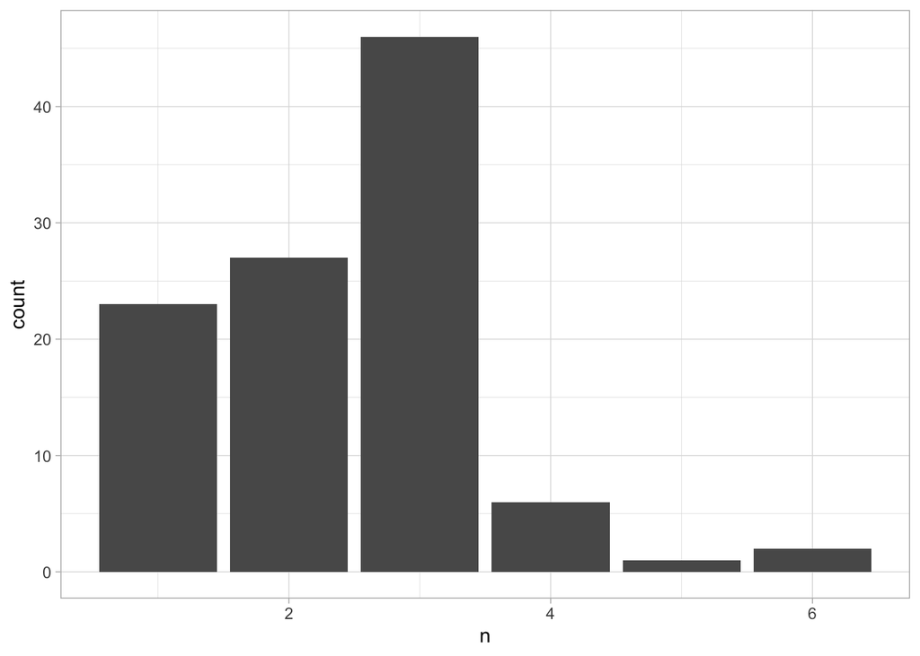

```r
df %>%
  count(player_id) %>%
  ggplot(aes(x = n)) +
  geom_bar(stat = "count")
```

Drop anyone with only 1 test since they don’t have multiple tests to use in the analysis.

```r
df <- df %>%
  group_by(player_id) %>%
  filter(n() > 1) %>%
  ungroup()
```

How many players does this leave us with?

```r
df %>%
  count(player_id) %>%
  nrow()
```

```
## [1] 82
```

Get the quantiles of the number of tests these players did:

```r
df %>%
  count(player_id) %>%
  summarize(q = c(0, 0.25, 0.5, 0.75, 1),
            quantiles = quantile(n, probs = c(0, 0.25, 0.5, 0.75, 1)))
```

```
## # A tibble: 5 × 2
##       q quantiles
##   <dbl>     <dbl>
## 1  0            2
## 2  0.25         2
## 3  0.5          3
## 4  0.75         3
## 5  1            6
```

## Test-Retest Analysis

Before delving into measuring variance in serial measurement, let’s start with a test-retest analysis. Here, we will operate as if the first two tests represent the test-retest trials we care about. Generally, these two tests are taken in the early season (one test at pre-season physical testing day and the second test a week later).

Start by getting the first two tests for each player

```r
test_retest <- df %>%
  group_by(player_id) %>%
  filter(n() <= 2) %>%
  mutate(test_num = row_number()) %>%
  ungroup()
```

Plot the test results for each athlete

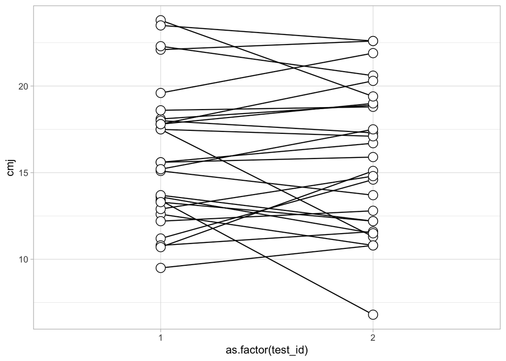

```r
test_retest %>%
  group_by(player_id) %>%
  mutate(test_id = row_number()) %>%
  ggplot(aes(x = as.factor(test_id), y = cmj, group = player_id)) +
  geom_line() +
  geom_point(shape = 21,
             size = 4,
             color = "black",
             fill = "white")
```

Plot the measurement between between the two tests (the variance is represented as the amount of distance each dot is from the 45 degree diagonal line)

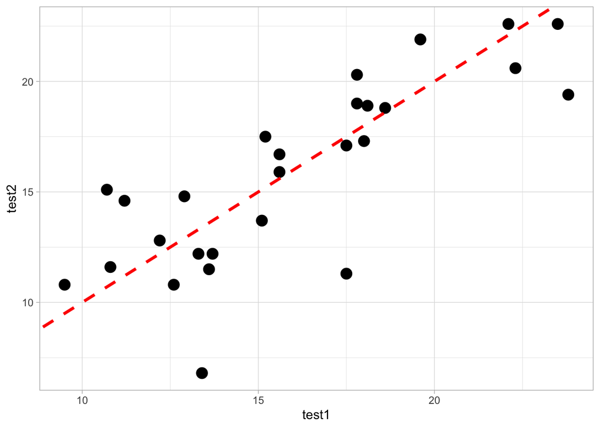

```r
# get data into wide format to create a cmj_1 ands cmj_2 column, reflecting the two tests
test_retest_wide <- test_retest %>%
  select(player_id, test_num, cmj) %>%
  pivot_wider(names_from = test_num,
              values_from = cmj) %>%
  rename(test1 = '1',
         test2 = '2')

test_retest_wide %>%
  ggplot(aes(x = test1, y = test2)) +
  geom_point(size = 4) +
  geom_abline(intercept = 0,
              slope = 1,
              color = "red",
              size = 1.2,
              linetype = "dashed")
```

Calculate a paired t-test to evaluate whether there is a difference between the two tests.

```r
with(test_retest_wide, t.test(test1, test2, paired = TRUE))
```

```
##
##  Paired t-test
##
## data:  test1 and test2
## t = 0.38519, df = 26, p-value = 0.7032
## alternative hypothesis: true mean difference is not equal to 0
## 95 percent confidence interval:
##  -0.8351678  1.2203530
## sample estimates:
## mean difference
##       0.1925926
```

**Variance**

An athlete’s true score is a representation of their observed score plus some level of error.

$Y_i = n + e_i$

The variance for observed scores can calculated as:

$sigma^2(Y_i) = sigma^2(n) + sigma^2(e)$

Where: * sigma^2(Y_i) = the total variance * sigma^2(n) = true variance * sigma^2(e) = the error variance

We can explore this variance using a linear mixed model, given the repeated measures for the athletes.

```r
fit_lmer <- lmer(cmj ~ 1 + (1|player_id), data = test_retest)
summary(fit_lmer)
```

```
## Linear mixed model fit by REML ['lmerMod']
## Formula: cmj ~ 1 + (1 | player_id)
##    Data: test_retest
##
## REML criterion at convergence: 274.8
##
## Scaled residuals:
##      Min       1Q   Median       3Q      Max
## -2.17492 -0.49009  0.04333  0.37848  1.62411
##
## Random effects:
##  Groups    Name        Variance Std.Dev.
##  player_id (Intercept) 13.372   3.657
##  Residual               3.269   1.808
## Number of obs: 54, groups:  player_id, 27
##
## Fixed effects:
##             Estimate Std. Error t value
## (Intercept)  15.9037     0.7455   21.33
```

```r
## extract the relevant components
var_players <- 13.372
var_resid <- 3.269
var_total <- var_players + var_resid

data.frame(
  var_players,
  var_resid,
  var_total
) %>%
  knitr::kable()
```

| var_players | var_resid | var_total |
| --- | --- | --- |
| 13.372 | 3.269 | 16.641 |

Using these variances we can calculate an ICC from our mixed model:

$ICC = variance.players / total.variance)$

```r
icc <- round(var_players / var_total, digits = 2)
cat("The ICC from this mixed model is", icc)
```

```
## The ICC from this mixed model is 0.8
```

NOTE: We can get the same value using the `pych` packages built in `ICC()` function, which provides an ICC for a number of different types of rater options. It additionally provides you with the 95% confidence intervals.

```r
psych::ICC(test_retest_wide[, 2:3])
```

```
## boundary (singular) fit: see help('isSingular')
```

```
## Call: psych::ICC(x = test_retest_wide[, 2:3])
##
## Intraclass correlation coefficients
##                          type  ICC   F df1 df2       p lower bound upper bound
## Single_raters_absolute   ICC1 0.80 9.2  26  27 8.5e-08        0.62        0.91
## Single_random_raters     ICC2 0.80 9.2  26  26 1.3e-07        0.62        0.91
## Single_fixed_raters      ICC3 0.80 9.2  26  26 1.3e-07        0.61        0.91
## Average_raters_absolute ICC1k 0.89 9.2  26  27 8.5e-08        0.76        0.95
## Average_random_raters   ICC2k 0.89 9.2  26  26 1.3e-07        0.76        0.95
## Average_fixed_raters    ICC3k 0.89 9.2  26  26 1.3e-07        0.76        0.95
##
##  Number of subjects = 27     Number of Judges =  2
## See the help file for a discussion of the other 4 McGraw and Wong estimates,
```

**Calculate the difference between the two tests**

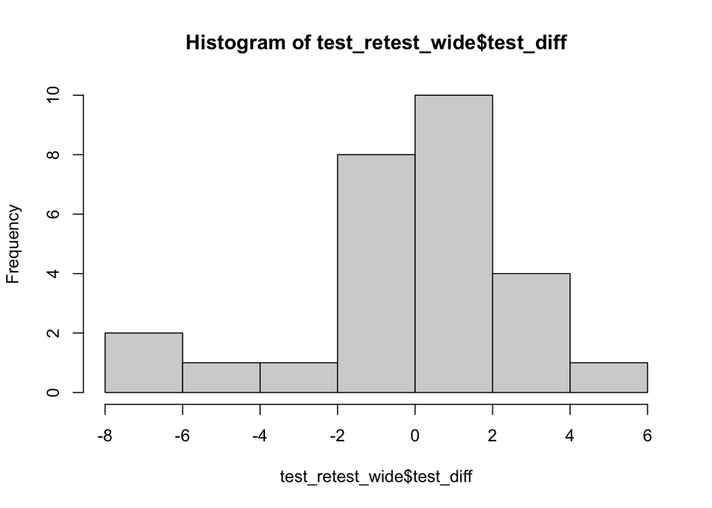

```r
test_retest_wide <- test_retest_wide %>%
  mutate(test_diff = test2 - test1)

hist(test_retest_wide$test_diff)
```

**Calculating Typical Error Measurement (TEM) and Standard Error Measurement (SEM)**

De Vet & Terwee (*Measurement in Medicine*) suggest that a Standard Error of Measurement for consistency can be calculated as follows:

$sem.consistency = sd.difference / sqrt(2)$

This measurement has also been referred to by Weir (quoting Hopkins) as the Typical Error Measurement (TEM)

```r
tem <- sd(test_retest_wide$test_diff) / sqrt(2)
tem
```

```
## [1] 1.83711
```

We can also reflect the `tem` as a Coefficient of Variation as well

```r
tem / mean(test_retest$cmj)
```

```
## [1] 0.1155146
```

As a side note, sqrt(2) in the denominator reflects the notion that we are using a difference between two tests, each based on their own measurement error, indicating that we have twice the measurement error present in the variances.

An alternative approach to calculating the Standard Error of Measurement, also recommended De Vet and Terwee, is:

$sem.consistency = sqrt(var_resid)$

```r
sem <- sqrt(var_resid)
sem
```

```
## [1] 1.808038
```

An alternative approach to calculate the `sem` (Harvill, 1991) is:

$sem = sqrt(sd^2 * (1 - icc))$

```r
sem2 <- sqrt(sd(test_retest$cmj)^2 * (1 - icc))
sem2
```

```
## [1] 1.81043
```

Or as a coefficient of variation

```r
sem2 / mean(test_retest$cmj)
```

```
## [1] 0.113837
```

The same value is obtained by transforming the variance to a standard deviation and leaving it outside of the `sqrt()` function.

$sem = sd * sqrt(1 - icc)$

```r
sd(test_retest$cmj) * sqrt(1 - icc)
```

```
## [1] 1.81043
```

Taking this same `sem` approach, De Vet & Terwee recommend using a pooled standard deviation instead:

$sd.pooled = sqrt((sd_1^2 + sd_2^2) / 2)$

```r
sd_pooled <- sqrt(( sd(test_retest_wide$test1)^2 + sd(test_retest_wide$test2)^2 ) / 2)

sd_pooled * sqrt(1 - icc)
```

```
## [1] 1.827228
```

However, they take issue with this method of calculating the `sem` because they suggest that it is mainly used by those who are not calculating their own test-retest trial and just using an ICC from the scientific literature, which might not apply to their population (not an issue here, however).

**Calculate the SWC and Minimal Difference**

Hopkins suggests the Smallest Worthwhile change to be a Cohen’s d effect size of 0.2 (which Cohen indicated was a *small* effect) multiplied by the between subject standard deviation of the test.

```r
swc <- sd(test_retest_wide$test1) * 0.2
swc
```

```
## [1] 0.8
```

This value is incredibly small and using this approach for SWC it always seems to come out very small (especially if the population is homogenous), so I find it a bit weird. Of course, we can increase the effect size magnitude, say from 0.2 to 1 (more of a large effect).

The **minimal difference (MD)**, as discussed by Weir, is calculated as follows:

$md = sem * 1.96 * sqrt(2)$

- NOTE: The 1.96 is specific to the confidence level of interest. In this case, 1.96 represents a z-critical value for a 95% level of confidence.

```r
md <- sem2 * 1.96 * sqrt(2)
md
```

```
## [1] 5.018257
```

This value is much larger and suggests that we would need to see a test change of greater than 5 inches of jump height to feel that the change is outside of the error measurement of the test. A 5 inch change in jump height would be massive for an elite population.

**What about on a log scale?**

Okay, before I move on to calculating confidence intervals around each player’s observed score, to determine the range of plausible outcomes for `true score`, I want to pause and do all of the above on a log scale.

Why a log scale?

Often, we might be dealing with non-uniformity bias in the raw scores. For example, jump height and impulse will different greatly between smaller players (e.g., WR and DB) and larger players (e.g., DL). Thus, instead of reflecting the error measurement and the minimal difference on a raw scale, we might want to evaluate it as a percentage change. The log transformation will help us do just that.

First, calculate the difference of the log performance

```r
test_retest_wide <- test_retest_wide %>%
  mutate(diff_log = log(test2) - log(test1))
```

Exponentiating the values will put them on a ratio scale and then subtracting 1 gets us to a percentage scale.

```r
## TEM as a coefficient of variation
tem_log <- sd(test_retest_wide$diff_log) / sqrt(2)
tem_cv_log <- exp(tem_log) - 1
tem_cv_log
```

```
## [1] 0.1541219
```

Looking at our `tem CV%` here, we have a 15% error in measurement. This is slighlty higher than calculating the `tem CV%` on the normal scale of the data, which was around 11.5%.

Finally, we calculate the SWC as percentages instead of raw values

```r
## SWC%
swc_percent <- exp(0.2*sd(log(test_retest_wide$test1))) - 1
swc_percent
```

```
## [1] 0.05155845
```

**True Scores**

Since we now have an `sem` for the test, we can calculate confidence around the player’s observed score to explore what we think their true score might be. This works because recall that:

$True.Score = Observed.Score + error$

Thus, the confidence interval for a true score can be estimated, as discussed in Weir (2005) and Swinton et al (2018), as:

$True.Score = Observed.Score + z.critical value * SEM$

Let’s calculate the true score 95% CI based on `cmj_1`

```r
test_retest_wide <- test_retest_wide %>%
  mutate(low95 = test1 - 1.96*sem2,
         high95 = test1 + 1.96*sem2)

test_retest_wide %>%
  head() %>%
  knitr::kable()
```

| player_id | test1 | test2 | test_diff | diff_log | low95 | high95 |
| --- | --- | --- | --- | --- | --- | --- |
| 125643 | 15.1 | 13.7 | -1.4 | -0.0972989 | 11.551557 | 18.64844 |
| 140125 | 9.5 | 10.8 | 1.3 | 0.1282543 | 5.951557 | 13.04844 |
| 147297 | 17.5 | 11.3 | -6.2 | -0.4373982 | 13.951557 | 21.04844 |
| 156561 | 11.2 | 14.6 | 3.4 | 0.2651078 | 7.651557 | 14.74844 |
| 166828 | 15.6 | 16.7 | 1.1 | 0.0681378 | 12.051557 | 19.14844 |
| 174286 | 18.1 | 18.9 | 0.8 | 0.0432500 | 14.551557 | 21.64844 |

Now plot the observed score and the confidence interval for the true score for a few players.

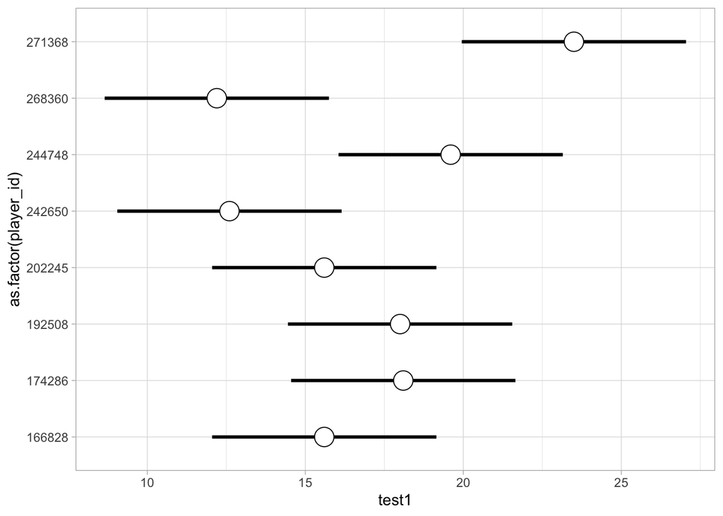

```r
test_retest_wide %>%
  sample_n(8) %>%
  ggplot(aes(x = test1, y = as.factor(player_id))) +
  geom_errorbar(aes(xmin = low95, xmax = high95),
                width = 0,
                size = 1.1) +
  geom_point(shape = 21,
             color = "black",
             fill = "white",
             size = 6)
```

## Serial Analysis

Often, in a pro or collegiate sports environment we don’t have the luxury of conducting test-retest trials due to time constraints. Additionally, the variance from week-to-week might be larger than what we would see in a controlled test-retest analysis, leading us to identifying a large number of athletes each week who are believed to be exhibiting a change (false positive).

There are a few options we could consider here:

1. Use the first two tests for the athletes to determine a sort of “test-retest” environment, even if the tests are a week apart, and operate under the assumption that the variance we observe is similar to what we will see across the season. This was the approach taken above.
2. Use a few weeks to establish week-to-week variance, assume those weeks to be a “baseline” phase, and then use the analysis of the baseline phase to inform decisions for all subsequent weeks. This is the approach suggested in Weakley et al (2021), when discussing changes observed using velocity-based training (I re-coded that entire paper HERE. This isn’t a bad approach other than the notion that I’ve never seen a real “baseline” training phase in the NFL. Each phase of training has been dedicated to preparing for competitions, so the training demand has always been high and fluctuating based on where the team is in the week. However, maybe we don’t need to consider a true baseline phase as much as we take the first few tests of each player and calculate the weekly fluctuation and then use that information going forward, which was in line with the approach suggested by Bagger et al.
3. Use a prior season’s worth of data to model the expected week-to-week variance. This is relatively similar to approach 2, just with way more data.

**Plot those with more than 3 tests**

Unfortunately, this is an old data set and not indicative of how we capture CMJ now (not even the same technology). Over the past several years we have been collecting weekly counter movement jumps on force plates. The data here is Optojump data and was recorded at a less frequent rate.

Recall that we have the following distribution of within-individual observations:

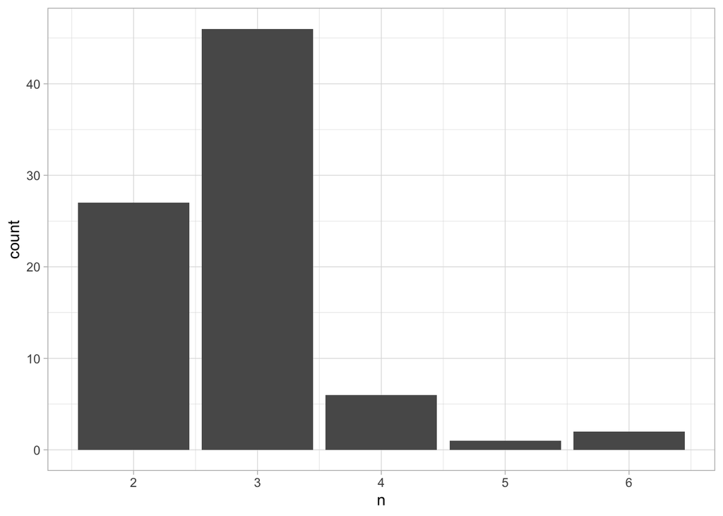

```r
df %>%
  count(player_id) %>%
  ggplot(aes(x = n)) +
  geom_bar(stat = "count")
```

Although the majority of the players had 3 jumps during the season there are a number of players with more than 3 jumps (9 players).

```r
df %>%
  count(player_id) %>%
  tally(n > 3)
```

```
## # A tibble: 1 × 1
##       n
##   <int>
## 1     9
```

We will concentrate on these players as identifying whether a particular test is outside of error measurement and the minimial difference established above. Additionally, we will use the first 3 tests of the entire population as our “serial measurements”, as explained in point 2 above, to determine the week-to-week variance and, subsequently, whethere these 9 players are exhibiting changes outside of that normal variance.

Since we have already determined our SEM and MD above, we need to handle the serial measurements piece. Let’s grab everyone’s first three tests.

```r
test3 <- df %>%
  group_by(player_id) %>%
  mutate(test_num = row_number(),
         max_test = max(test_num)) %>%
  ungroup() %>%
  filter(max_test == 3)

test3 %>%
  head() %>%
  knitr::kable()
```

| player_id | position | date | cmj | test_num | max_test |
| --- | --- | --- | --- | --- | --- |
| 172493 | CB | 2019-04-15 | 21.5 | 1 | 3 |
| 172493 | CB | 2019-06-10 | 19.4 | 2 | 3 |
| 172493 | CB | 2019-07-24 | 20.0 | 3 | 3 |
| 172833 | QB | 2019-04-15 | 15.4 | 1 | 3 |
| 172833 | QB | 2019-06-10 | 16.3 | 2 | 3 |
| 172833 | QB | 2019-07-24 | 15.5 | 3 | 3 |

We have the data stored in a long format. We can pivot it to a wider format to help us create a new column of mean and SD for each player’s serial tests. NOTE: We could do this in the log format with lag functions, but it might help us to visualize it better in a wide format.

```r
test3_wide <- test3 %>%
  select(player_id, test_num, cmj) %>%
  pivot_wider(names_from = test_num,
              values_from = cmj) %>%
  rename(test1 = '1',
         test2 = '2',
         test3 = '3')

test3_wide %>%
  head() %>%
  knitr::kable()
```

| player_id | test1 | test2 | test3 |
| --- | --- | --- | --- |
| 172493 | 21.5 | 19.4 | 20.0 |
| 172833 | 15.4 | 16.3 | 15.5 |
| 191713 | 18.8 | 16.3 | 17.5 |
| 195069 | 18.8 | 20.6 | 20.3 |
| 197077 | 18.8 | 16.1 | 19.6 |
| 199319 | 15.5 | 14.3 | 16.5 |

Now let’s create a column representing the mean, standard deviation, and coefficient of variation for each player across their 3 tests.

```r
test3_wide$Avg <- apply(test3_wide[, c("test1", "test2", "test3")], MARGIN = 1, FUN = mean)
test3_wide$Sd <- apply(test3_wide[, c("test1", "test2", "test3")], MARGIN = 1, FUN = sd)
test3_wide$CV_pct <- with(test3_wide, round(Sd / Avg, 3))

test3_wide %>%
  head() %>%
  knitr::kable()
```

| player_id | test1 | test2 | test3 | Avg | Sd | CV_pct |
| --- | --- | --- | --- | --- | --- | --- |
| 172493 | 21.5 | 19.4 | 20.0 | 20.30000 | 1.0816654 | 0.053 |
| 172833 | 15.4 | 16.3 | 15.5 | 15.73333 | 0.4932883 | 0.031 |
| 191713 | 18.8 | 16.3 | 17.5 | 17.53333 | 1.2503333 | 0.071 |
| 195069 | 18.8 | 20.6 | 20.3 | 19.90000 | 0.9643651 | 0.048 |
| 197077 | 18.8 | 16.1 | 19.6 | 18.16667 | 1.8339393 | 0.101 |
| 199319 | 15.5 | 14.3 | 16.5 | 15.43333 | 1.1015141 | 0.071 |

**Understanding Variability in our Data**

There are 3 sources of test variability we can choose to explore:

1. Total Variability – The standard deviation of all CMJ tests
2. Between-Subject Variability – The standard deviation of all athletes Avg CMJ performance (the Avg encompasses each athlete’s own variability )
3. Within-Subject Variability – The average of each athlete’s standard deviation (the average variability of everyone’s own variability)

```r
total_variability <- sd(c(test3_wide$test1, test3_wide$test2, test3_wide$test3))

# NOTE: Could have calculated total_variability with the long data set as well: sd(test3$cmj)

btw_subject_variability <- sd(test3_wide$Avg)

within_subject_variability <- mean(test3_wide$Sd)

data.frame(total_variability, btw_subject_variability, within_subject_variability) %>%
  knitr::kable()
```

| total_variability | btw_subject_variability | within_subject_variability |
| --- | --- | --- |
| 2.77015 | 2.609481 | 1.04168 |

Notice that if we take these measures of variability and square them (to make them variances), the sum of the `btw_subject_variability` and `within_subject_variability` is nearly the same as the `total_variability`.

```r
total_variability ^ 2
```

```
## [1] 7.673732
```

```r
btw_subject_variability ^ 2 + within_subject_variability ^ 2
```

```
## [1] 7.894489
```

We can reflect all of this as Coefficients of Variation as well

```r
total_variability_cv <- sd(c(test3_wide$test1, test3_wide$test2, test3_wide$test3)) / mean(c(test3_wide$test1, test3_wide$test2, test3_wide$test3))

btw_subject_variability_cv <- sd(test3_wide$Avg) / mean(test3_wide$Avg)

within_subject_variability_cv <- mean(test3_wide$Sd) / mean(c(test3_wide$test1, test3_wide$test2, test3_wide$test3))

data.frame(total_variability_cv, btw_subject_variability_cv, within_subject_variability_cv) %>%
  knitr::kable()
```

| total_variability_cv | btw_subject_variability_cv | within_subject_variability_cv |
| --- | --- | --- |
| 0.1628736 | 0.153427 | 0.0612466 |

**Partitioning variability using repeated measures ANOVA**

First, to conduct this analysis, we need to make sure the `player_id` and the `test_num` variables are factor levels instead of numeric, since we don’t want the model to see them as continuous variables. I’ll also explicity set the factor levels of the `test_num` variable since the order (1, 2, 3) might matter here.

```r
test3 <- test3 %>%
  mutate(player_id = as.factor(player_id),
         test_num = as.factor(test_num),
         test_num = factor(test_num, levels = c("1", "2", "3")))
```

Now conduct a repeated measures ANOVA

```r
repeat_aov <- aov(cmj ~ test_num + Error(player_id), data = test3)
summary(repeat_aov)
```

```
##
## Error: player_id
##           Df Sum Sq Mean Sq F value Pr(>F)
## Residuals 45  919.3   20.43
##
## Error: Within
##           Df Sum Sq Mean Sq F value Pr(>F)
## test_num   2  10.61   5.305   3.932 0.0231 *
## Residuals 90 121.42   1.349
## ---
## Signif. codes:  0 '***' 0.001 '**' 0.01 '*' 0.05 '.' 0.1 ' ' 1
```

- NOTE: We could have done this repeated measures ANVOA in the first section, with the test-retest analysis, and used these variances to calculate an ICC by hand (see Weir, 2005). We can additionally calculate an ICC with 3 tests per player using the same mathematical expressions, which I wont walk through here.

**Mixed Model approach**

We can alternatively partition the variability of the data using a mixed model, which will handle repeated measures and relax the assumption of sphericity that a repeated measures ANOVA has.

```r
repeat_lmer <- lmer(cmj ~ test_num + (1|player_id), data = test3)
summary(repeat_lmer)
```

```
## Linear mixed model fit by REML ['lmerMod']
## Formula: cmj ~ test_num + (1 | player_id)
##    Data: test3
##
## REML criterion at convergence: 557.3
##
## Scaled residuals:
##      Min       1Q   Median       3Q      Max
## -2.12535 -0.51241 -0.04204  0.54231  2.39456
##
## Random effects:
##  Groups    Name        Variance Std.Dev.
##  player_id (Intercept) 6.360    2.522
##  Residual              1.349    1.162
## Number of obs: 138, groups:  player_id, 46
##
## Fixed effects:
##             Estimate Std. Error t value
## (Intercept)  17.2761     0.4094  42.202
## test_num2    -0.6500     0.2422  -2.684
## test_num3    -0.1543     0.2422  -0.637
##
## Correlation of Fixed Effects:
##           (Intr) tst_n2
## test_num2 -0.296
## test_num3 -0.296  0.500
```

Notice that the standard deviations from our repeated measures are very close to what we observed with our crude measures of variability above.

Another thing to be mindful of is that, because we have a random intercept the random effects represent the between and within (residual) standard deviation of the intercept. The fixed effect intercept represents the mean response in the population. Consequently, a coefficient of variation for between and within subject can be calculated by dividing the respective random effects by the intercept. In doing so, we end up with roughly the exact values that we obtained with our more crude measures, above.

```r
# between subject CV%
2.522 / 17.2761
```

```
## [1] 0.145982
```

```r
# Within subject CV%
1.162 / 17.2761
```

```
## [1] 0.06726055
```

The between-subject CV% from our mixed model is 14.5% while the crude version above was 15.3%. The within-subject CV% from the mixed model is 6.7% which is similar to the the crude calculation of CV%, which was 6.1%.

Notice that we can also calculate this mixed model on a log scale and simply exponentiate the random effects standard deviations and subtract 1, reflecting them as a CV%. We are left with relatively the same values with subtle differences given what log transformation does to the original scale that the data were on (but still very close with this data set).

```r
summary(lmer(log(cmj) ~ test_num + (1|player_id), data = test3))
```

```
## Linear mixed model fit by REML ['lmerMod']
## Formula: log(cmj) ~ test_num + (1 | player_id)
##    Data: test3
##
## REML criterion at convergence: -196.6
##
## Scaled residuals:
##      Min       1Q   Median       3Q      Max
## -2.35237 -0.45964  0.01944  0.54910  2.51976
##
## Random effects:
##  Groups    Name        Variance Std.Dev.
##  player_id (Intercept) 0.02450  0.15653
##  Residual              0.00501  0.07078
## Number of obs: 138, groups:  player_id, 46
##
## Fixed effects:
##              Estimate Std. Error t value
## (Intercept)  2.835786   0.025329 111.959
## test_num2   -0.041755   0.014759  -2.829
## test_num3   -0.006701   0.014759  -0.454
##
## Correlation of Fixed Effects:
##           (Intr) tst_n2
## test_num2 -0.291
## test_num3 -0.291  0.500
```

```r
# between subject CV%
exp(0.15653)-1
```

```
## [1] 0.1694458
```

```r
# within subject CV%
exp(0.07078)-1
```

```
## [1] 0.07334506
```

**What aout SWC?**

As discussed in the previous section, Hopkins suggests that the SWC is 0.2 * between subject SD.

Using our mixed model that leaves us with:

```r
2.522 * 0.2
```

```
## [1] 0.5044
```

As in the previous section, this value is small. Basically, a change of 0.5 inches in jump height would be a change we should care about.

Hopkins also suggests that we can calculate a SWC with the Between Subject Coefficient of Variation by multiplying it by 0.3:

```r
0.145 * 0.3
```

```
## [1] 0.0435
```

Or from the log scaled model:

```r
0.169 * 0.3
```

```
## [1] 0.0507
```

So, roughly a change of around 5% in jump height would be meaningful. I don’t *love* this because the 0.3 effect came from Hopkins’ analysis of sprinters and determining that the smallest meaningful change in performance to make a podium finish was an effect size of 0.3, which might not be appropriate for other sports.

We can plot the data for the players that had over 3 tests. We will reflect the MD as a grey shaded region of 6.8% around 0. Additionally, we will add error bars of the within individual variation of 6.7% aronund each of our observed points, to give a picture of uncertainty.

```r
sem_new <- sqrt(sd(test3$cmj)^2 * (1 - 0.825))
sem_new / mean(test3$cmj)
```

```
## [1] 0.06813493
```

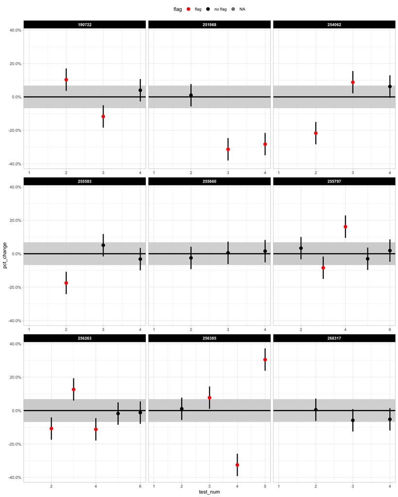

```r
df %>%
  group_by(player_id) %>%
  mutate(test_num = row_number(),
         max_test = max(test_num)) %>%
  ungroup() %>%
  filter(max_test > 3) %>%
  group_by(player_id) %>%
  mutate(pct_change = (cmj - lag(cmj)) / lag(cmj),
         flag = ifelse(abs(pct_change) > 0.068, "flag", "no flag")) %>%
  ggplot(aes(x = test_num, y = pct_change)) +
  geom_rect(aes(ymin = 0 - 0.068, ymax = 0 + 0.068),
            xmin = 0,
            xmax = Inf,
            fill = "light grey",
            alpha = 0.4) +
  geom_hline(yintercept = 0,
             size = 1.2) +
  geom_errorbar(aes(ymin = pct_change - 0.067,
                    ymax = pct_change + 0.067),
                size = 1.1,
                width = 0) +
  geom_point(size = 3,
             aes(color = flag)) +
  scale_y_continuous(labels = scales::percent_format(accuracy = 0.1)) +
  scale_color_manual(values = c("flag" = "red", "no flag" = "black", na.value = "black")) +
  facet_wrap(~player_id, scales = "free_x") +
  theme(legend.position = "top",
        strip.background = element_rect(fill = "black"),
        strip.text = element_text(color = "white", face = "bold"))
```

Alternatively, we can alternatively flag players using the test-retest analysis. Let’s apply those flags to this group of 9 athletes. On the log scale, we found that `swc_percent = 0.052` so we will use 5% to flag players. We will also add a flag that is only triggered when the player has a change that is larger than the `tem_cv_log` which was our TEM as a CV% from the log scale, which was 15%.

To show the effect of using these different approaches we will count the times that the different flag approaches aggered or not.

```r
df %>%
  group_by(player_id) %>%
  mutate(test_num = row_number(),
         max_test = max(test_num)) %>%
  ungroup() %>%
  filter(max_test > 3) %>%
  group_by(player_id) %>%
  mutate(pct_change = (cmj - lag(cmj)) / lag(cmj),
         flag_serial = ifelse(abs(pct_change) > 0.068, "flag", "no flag"),
         flag_swc_pct = ifelse(abs(pct_change) > 0.05, "flag", "no flag"),
         flag_tem_pct = ifelse(abs(pct_change) > 0.154, "flag", "no flag")) %>%
  ungroup() %>%
  filter(!is.na(pct_change)) %>%
  count(flag_serial, flag_swc_pct, flag_tem_pct)
```

```
## # A tibble: 4 × 4
##   flag_serial flag_swc_pct flag_tem_pct     n
##   <chr>       <chr>        <chr>        <int>
## 1 flag        flag         flag             7
## 2 flag        flag         no flag          8
## 3 no flag     flag         no flag          4
## 4 no flag     no flag      no flag         13
```

- 7 times all three suggested to flag a change
- 8 times all `flag_serial` and `flag_swc_pct` suggested to flag the change while `flag_tem_pct` suggested no flag. This makes sense given how close the former two are to each other.
- 4 times the `flag_swc_pct` indicated a meaningful change while the other two did not.
- 13 times all three approaches indicated `no flag`

## Paths Forward

There are so many things to consider with all this stuff and I feel like the more I write it all out the less I know because I realize there are all of these bottlenecks and assumptions that people seem to just hand wave over when they publish a paper.

A nice path forward would be to make this approach Bayesian where we can estimate a posterior distribution for each player and then express the amount/mass of that distribution that is exceeding the minimal change/SWC to help the pracitioners calibrate their sense of tolerance for risk and perhaps have meaningful discussions about when/if it is time to intervene on a player’s physical preparation.